# Practical Machine Learning project writeup

Sunday, June 21, 2015

## Introduction

In this report, I analyze the weight lifting technique recognition data located at http://groupware.les.inf.puc-rio.br/har. In this experiment, six subjects were asked to lift a dumbbell correctly a number of times, and then incorrectly a number of times in four different ways. So there were a total of five types of lifting motions. Each observation had a wide variety of data measured from various sensors on the subjects’ bodies. The goal of this report was to train a machine learning model to examine the data and determine which type of lifting motion was used.

## Examining and Cleaning the Data

One of the first things I noticed was that many of the columns had a lot of NA’s in them. A column that is mostly empty (or mostly one value) doesn’t generally provide much information, particularly since the portion of classes (A, B, C, D, and E) are relatively equal. So I wrote a function to calculate the percentatage of NA and blank values in a column. Doing something like

```r
set.seed(29185);
pmltraining <- read.csv("pml-training.csv");
pmltesting <- read.csv("pml-testing.csv");
pml <- pmltraining;
b <- 1;
#sapply(pml[,b], function(b) { print(paste(b, names(pml)[b], class(pml[,b]),fractionEmpty(pml[,b])))});
```

will list all the order, name, and class of each column along with the fraction of NAs or blanks in that column. Many columns were about 98% NA or blank. While a sophisticated model may ignore columns that have blanks or little variation, I didn’t want the possibility of them throwing off the results, and I didn’t want the added processing time, so I removed these columns.

I also noticed that there were columns for timestamp and user name, which also have little relevance for the class. Also, an astute data scientist might notice that the classe variable was arranged as all A for about the first fifth, then all B, then all C, then all D, then all E, so timestamp could be related to the class if the subjects were asked to do the each class of exercise in order. But in general time and class may not be related.

This did cause trouble at one point, because when I first did the analysis with Random Forests, training on half the training set and validating on the other half, I got 100% accuracy. This looked suspicious, and getting all A on the 20 test cases also looked suspicious. But I could not find anything wrong with the code so I submitted one answer…and got it wrong. I went back and looked and realized I had not removed the “X” column and “num_window” column. Those columns increase as you go up. This means on the training set, you can use this to predict the class, but it is merely because of how the data is arranged. But the test set did not seem to follow that convention. See the appendix for how easy it is to use the X column to predict the results of the training set.

Below is the code I settled on for cleaning.

```r
require(caret);
TRAINING_RATIO <- .1#.66666667;
source("C:/Users/paul/Coursera/datascience/predmachlearn/project/project.r")
old_pml <- pmltesting;
removeUnnecessaryColumns <- function(old_pml) {
  #first, remove columns that are mostly null or blank
  b <- 1; i <- 2;
  #sapply(pml[,b], function(b) { print(paste(b, names(pml)[b], class(pml[,b]),fractionNA(pml[,b]))});

  new_pml <- data.frame(old_pml[,1])
  names(new_pml) <- names(old_pml[1])

  for(b in 2:160) { if(fractionEmpty(old_pml[,b]) < .5) { new_pml <- cbind(new_pml, old_pml[,b]);}}
  for(b in 2:160) { if(fractionEmpty(old_pml[,b]) < .5) { names(new_pml)[i] <- names(old_pml)[b]; i <- i + 1}}


  #remove columns that are not relevant, like timestamps
  names(new_pml)
  cnames <- names(new_pml); #just to make the next line a little shorter
  to_remove <- c(grep("X", cnames), grep("user_name",cnames), grep("num_window", cnames),
                 grep("raw_timestamp_part_1", cnames), grep("raw_timestamp_part_2", cnames),
                 grep("cvtd_timestamp", cnames), grep("new_window",cnames));
  new_pml <- new_pml[-to_remove]

  #removing the timestamps because they don't seem to be relevant
  #removing new_window because almost 98% are no and it does not seem to convey useful information

  #now randomize the order so we don't have all the same type if we do k-fold cross validation (should not be necessary but shouldn't hurt)
  new_indices <- sample(1:dim(new_pml)[1], replace=FALSE);
  new_pml <- new_pml[new_indices,];
  return(new_pml);
}

#copy to new variables so I still have the originals if I remove something I shouldn't.
pml <- removeUnnecessaryColumns(pmltraining);
pmltest <- removeUnnecessaryColumns(pmltesting);
```

## Training

I primarily worked with two models, Trees and Random Forests. I tried training a multiple variable linear model but realized that since the variable we are trying to predict is categorical (five classes) with no order, it does not make sence to use a linear model. Also, I had implemented Naive Bayes in Java previously and initially had hoped to try it but realized it would not work well. It can do well when both the input variables and output are categorical, but the inputs here are primarily numerical.

```r
#use the doParallel package to hopefully speed things up a little
library(doParallel)
cl <- makeCluster(detectCores())
registerDoParallel(cl)

inTrain <- createDataPartition(y=pml$classe, p = TRAINING_RATIO, list=F)
pml_train <- pml[inTrain,];
pml_validate <- pml[-inTrain,];

if(dim(pml_validate)[1] + dim(pml_train)[1] != dim(pml)[1]) { #should be equal
  stop("dimensions do not add up");
}

rpartModel <- train(classe ~ ., data=pml_train, method="rpart")
rpartModel$finalModel;
```

```
## n= 1964
##
## node), split, n, loss, yval, (yprob)
##       * denotes terminal node
##
##  1) root 1964 1406 A (0.28 0.19 0.17 0.16 0.18)
##    2) roll_belt< 130.5 1809 1252 A (0.31 0.21 0.19 0.18 0.11)
##      4) pitch_forearm< -28.15 174    6 A (0.97 0.034 0 0 0) *
##      5) pitch_forearm>=-28.15 1635 1246 A (0.24 0.23 0.21 0.2 0.13)
##       10) magnet_dumbbell_y< 450.5 1400 1015 A (0.28 0.18 0.24 0.19 0.11)
##         20) roll_forearm< 118.5 834  491 A (0.41 0.18 0.18 0.15 0.072) *
##         21) roll_forearm>=118.5 566  384 C (0.074 0.18 0.32 0.25 0.18) *
##       11) magnet_dumbbell_y>=450.5 235  112 B (0.017 0.52 0.034 0.23 0.2) *
##    3) roll_belt>=130.5 155    1 E (0.0065 0 0 0 0.99) *
```

```r
rPartValidation <- predict(rpartModel, pml_validate);
if(length(rPartValidation) != dim(pml_validate)[1]) {
  stop("prediction vector is the wrong length");
}

rfModel <- train(classe ~ ., data=pml_train, method="rf");
rfModel;
```

```
## Random Forest
##
## 1964 samples
##   52 predictor
##    5 classes: 'A', 'B', 'C', 'D', 'E'
##
## No pre-processing
## Resampling: Bootstrapped (25 reps)
##
## Summary of sample sizes: 1964, 1964, 1964, 1964, 1964, 1964, ...
##
## Resampling results across tuning parameters:
##
##   mtry  Accuracy   Kappa      Accuracy SD  Kappa SD
##    2    0.9124336  0.8889804  0.01125004   0.01421921
##   27    0.9164293  0.8940721  0.01139336   0.01438715
##   52    0.9056170  0.8803944  0.01481745   0.01861548
##
## Accuracy was used to select the optimal model using  the largest value.
## The final value used for the model was mtry = 27.
```

```r
rfModel$finalModel;
```

```
##
## Call:
##  randomForest(x = x, y = y, mtry = param$mtry)
##                Type of random forest: classification
##                      Number of trees: 500
## No. of variables tried at each split: 27
##
##         OOB estimate of  error rate: 6.16%
## Confusion matrix:
##     A   B   C   D   E class.error
## A 551   3   2   1   1  0.01254480
## B  30 330  18   1   1  0.13157895
## C   0  18 318   5   2  0.07288630
## D   1   4  21 295   1  0.08385093
## E   0   3   6   3 349  0.03324100
```

```r
rfValidation <- predict(rfModel, pml_validate);
if(length(rfValidation) != dim(pml_validate)[1]) {
  stop("prediction vector is the wrong length");
}


#stopCluster(cl);
```

## Training Results and Accuracy Estimates

Here are the accuracy results of the two models.

```r
confusionMatrix(rPartValidation, pml_validate$classe);
```

```
## Confusion Matrix and Statistics
##
##           Reference
## Prediction    A    B    C    D    E
##          A 4590 1454 1432 1297  474
##          B   49 1070   96  483  409
##          C  370  893 1551 1114  886
##          D    0    0    0    0    0
##          E   13    0    0    0 1477
##
## Overall Statistics
##
##                Accuracy : 0.492
##                  95% CI : (0.4846, 0.4994)
##     No Information Rate : 0.2844
##     P-Value [Acc > NIR] : < 2.2e-16
##
##                   Kappa : 0.3359
##  Mcnemar's Test P-Value : NA
##
## Statistics by Class:
##
##                      Class: A Class: B Class: C Class: D Class: E
## Sensitivity            0.9140   0.3131  0.50373   0.0000  0.45502
## Specificity            0.6314   0.9272  0.77618   1.0000  0.99910
## Pos Pred Value         0.4964   0.5078  0.32219      NaN  0.99128
## Neg Pred Value         0.9486   0.8491  0.88103   0.8361  0.89059
## Prevalence             0.2844   0.1935  0.17437   0.1639  0.18383
## Detection Rate         0.2599   0.0606  0.08784   0.0000  0.08364
## Detection Prevalence   0.5237   0.1193  0.27262   0.0000  0.08438
## Balanced Accuracy      0.7727   0.6202  0.63996   0.5000  0.72706
```

```r
confusionMatrix(rfValidation, pml_validate$classe);
```

```
## Confusion Matrix and Statistics
##
##           Reference
## Prediction    A    B    C    D    E
##          A 4940  189    8    6    2
##          B   20 3106  157   26   45
##          C   21  106 2856  159   48
##          D   39   12   51 2684   41
##          E    2    4    7   19 3110
##
## Overall Statistics
##
##                Accuracy : 0.9455
##                  95% CI : (0.9421, 0.9488)
##     No Information Rate : 0.2844
##     P-Value [Acc > NIR] : < 2.2e-16
##
##                   Kappa : 0.931
##  Mcnemar's Test P-Value : < 2.2e-16
##
## Statistics by Class:
##
##                      Class: A Class: B Class: C Class: D Class: E
## Sensitivity            0.9837   0.9090   0.9276   0.9274   0.9581
## Specificity            0.9838   0.9826   0.9771   0.9903   0.9978
## Pos Pred Value         0.9602   0.9261   0.8953   0.9494   0.9898
## Neg Pred Value         0.9934   0.9783   0.9846   0.9858   0.9906
## Prevalence             0.2844   0.1935   0.1744   0.1639   0.1838
## Detection Rate         0.2798   0.1759   0.1617   0.1520   0.1761
## Detection Prevalence   0.2914   0.1899   0.1807   0.1601   0.1779
## Balanced Accuracy      0.9837   0.9458   0.9523   0.9589   0.9779
```

As you can see, the Random Forest Model is significantly more accurate than the tree model.

## Prediction

It is now time to make predictions for the test cases. To do this, we simply use the predict() function as we did with validation, but now we use the test data set instead of the validation portion of the training data set.

```r
dim(pmltest)
```

```
## [1] 20 53
```

```r
rPartPrediction <- predict(rpartModel, pmltest);
rfPrediction <- predict(rfModel, pmltest);

finalModel <- rfModel;
rfFinalPrediction <- predict(finalModel, pmltest);

if(length(rfFinalPrediction) != dim(pmltest)[1]) {
  stop("prediction vector is the wrong length");
}
rfFinalPrediction;
```

```
##  [1] A B D A D E B B B A A E B A A B C E A A
## Levels: A B C D E
```

```r
#pml_write_files(rfFinalPrediction);
```

## Conclusion and Future Work

From the work detailed in this report, I conclude that a Random Forest model does a good job of predicting the classes of the validation data from the training data. However, this was only a very simple analysis, and further analysis could prove useful. Some of the things I would like to investigate are: * Tuning the parameters of the Random Forest Model. * Use Principal Component Analysis to analyze the correlations between the variables to see if some can be eliminated or combined. * Experiment with one or clustering algorithm to see if it outperforms Random Forests.

Finally, to further test this, I would like to see a much greater number of test cases (thousands, not 20).

## Appendix

To see the breakdown of classes and participants:

```r
source('C:/Users/paul/code/R/util.r');
factorHist(pmltraining$classe);
```

```
##   item counts  percents
## 1    A   5580 0.2843747
## 2    B   3797 0.1935073
## 3    C   3422 0.1743961
## 4    D   3216 0.1638977
## 5    E   3607 0.1838243
```

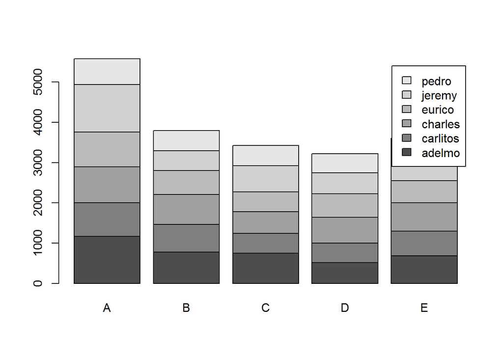

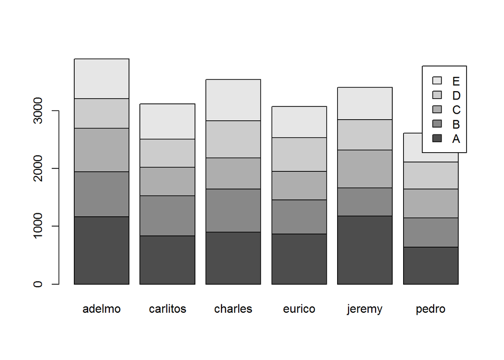

```
##           x y counts   xGivenY   yGivenX
## 1    adelmo A   1165 0.2087814 0.2993320
## 7    adelmo B    776 0.2043719 0.1993834
## 13   adelmo C    750 0.2191701 0.1927030
## 19   adelmo D    515 0.1601368 0.1323227
## 25   adelmo E    686 0.1901857 0.1762590
## 2  carlitos A    834 0.1494624 0.2679949
## 8  carlitos B    690 0.1817224 0.2217224
## 14 carlitos C    493 0.1440678 0.1584190
## 20 carlitos D    486 0.1511194 0.1561697
## 26 carlitos E    609 0.1688384 0.1956941
## 3   charles A    899 0.1611111 0.2542421
## 9   charles B    745 0.1962075 0.2106900
## 15  charles C    539 0.1575102 0.1524321
## 21  charles D    642 0.1996269 0.1815611
```

[output cut: 16 more lines]

```r
breakdown(pmltraining$user_name, pmltraining$classe)
```

factorHist() and breakdown() are functions I have previously written.

One thing I did at one point was to look at a summary of each column, which I did with the code below:

```r
#sapply(pml[,b], function(b) {
#  print(paste(b, names(pml)[b], class(pml[,b])));
#  print(summary(pml[,b]));
#  print(paste("sd: ", sd(pml[,b])));
#   if(is.numeric(pml[,b])) {
#     hist(pml[,b], main=paste("histogram of ", names(pml)[b]));
#   } else if(is.factor(pml[,b])) {
#     factorHist(pml[,b]);
#   }
# });
```

To see how well just the “X” variable predicts the class in the training set, look at this:

```r
pml_x <- pmltraining[,c(1,160)]
pml_x_train <- pml_x[inTrain,]
pml_x_validate <- pml_x[-inTrain,];

rfXModel <- train(classe ~ ., data=pml_x_train, method="rf");
rfXValidation <- predict(rfXModel, pml_x_validate);
confusionMatrix(rfXValidation, pml_x_validate$classe);
```

```
## Confusion Matrix and Statistics
##
##           Reference
## Prediction    A    B    C    D    E
##          A 5024    0    0    0    0
##          B    3 3391    6    0    0
##          C    0    0 3082    2    0
##          D    0    0    0 2910    0
##          E    0    0    0    3 3237
##
## Overall Statistics
##
##                Accuracy : 0.9992
##                  95% CI : (0.9987, 0.9996)
##     No Information Rate : 0.2847
##     P-Value [Acc > NIR] : < 2.2e-16
##
##                   Kappa : 0.999
##  Mcnemar's Test P-Value : NA
##
## Statistics by Class:
##
##                      Class: A Class: B Class: C Class: D Class: E
## Sensitivity            0.9994   1.0000   0.9981   0.9983   1.0000
## Specificity            1.0000   0.9994   0.9999   1.0000   0.9998
## Pos Pred Value         1.0000   0.9974   0.9994   1.0000   0.9991
## Neg Pred Value         0.9998   1.0000   0.9996   0.9997   1.0000
## Prevalence             0.2847   0.1920   0.1749   0.1651   0.1833
## Detection Rate         0.2845   0.1920   0.1745   0.1648   0.1833
## Detection Prevalence   0.2845   0.1925   0.1747   0.1648   0.1835
## Balanced Accuracy      0.9997   0.9997   0.9990   0.9991   0.9999
```

```r
rpartXModel <- train(classe ~ ., data=pml_x_train, method="rpart");
rpartXValidation <- predict(rpartXModel, pml_x_validate);
confusionMatrix(rpartXValidation, pml_x_validate$classe);
```

```
## Confusion Matrix and Statistics
##
##           Reference
## Prediction    A    B    C    D    E
##          A 5023    0    0    0    0
##          B    4 3391    6    0    0
##          C    0    0    0    0    0
##          D    0    0    0    0    0
##          E    0    0 3082 2915 3237
##
## Overall Statistics
##
##                Accuracy : 0.6598
##                  95% CI : (0.6528, 0.6668)
##     No Information Rate : 0.2847
##     P-Value [Acc > NIR] : < 2.2e-16
##
##                   Kappa : 0.5673
##  Mcnemar's Test P-Value : NA
##
## Statistics by Class:
##
##                      Class: A Class: B Class: C Class: D Class: E
## Sensitivity            0.9992   1.0000   0.0000   0.0000   1.0000
## Specificity            1.0000   0.9993   1.0000   1.0000   0.5841
## Pos Pred Value         1.0000   0.9971      NaN      NaN   0.3506
## Neg Pred Value         0.9997   1.0000   0.8251   0.8349   1.0000
## Prevalence             0.2847   0.1920   0.1749   0.1651   0.1833
## Detection Rate         0.2845   0.1920   0.0000   0.0000   0.1833
## Detection Prevalence   0.2845   0.1926   0.0000   0.0000   0.5229
## Balanced Accuracy      0.9996   0.9996   0.5000   0.5000   0.7921
```

```r
stopCluster(cl);
```